# week_06_seaborn_counting

## CMPINF 2100 Fall 2021 - Week 06

### Intro to Seaborn - counting

```python
import numpy as np
import pandas as pd
import matplotlib.pyplot as plt

import seaborn as sns
```

```python
penguins = sns.load_dataset('penguins')
```

```python
penguins.info()
```

```
<class 'pandas.core.frame.DataFrame'>
RangeIndex: 344 entries, 0 to 343
Data columns (total 7 columns):
 #   Column             Non-Null Count  Dtype
---  ------             --------------  -----
 0   species            344 non-null    object
 1   island             344 non-null    object
 2   bill_length_mm     342 non-null    float64
 3   bill_depth_mm      342 non-null    float64
 4   flipper_length_mm  342 non-null    float64
 5   body_mass_g        342 non-null    float64
 6   sex                333 non-null    object
dtypes: float64(4), object(3)
memory usage: 18.9+ KB
```

```python
penguins.describe()
```

|  | bill_length_mm | bill_depth_mm | flipper_length_mm | body_mass_g |
| --- | --- | --- | --- | --- |
| count | 342.000000 | 342.000000 | 342.000000 | 342.000000 |
| mean | 43.921930 | 17.151170 | 200.915205 | 4201.754386 |
| std | 5.459584 | 1.974793 | 14.061714 | 801.954536 |
| min | 32.100000 | 13.100000 | 172.000000 | 2700.000000 |
| 25% | 39.225000 | 15.600000 | 190.000000 | 3550.000000 |
| 50% | 44.450000 | 17.300000 | 197.000000 | 4050.000000 |
| 75% | 48.500000 | 18.700000 | 213.000000 | 4750.000000 |
| max | 59.600000 | 21.500000 | 231.000000 | 6300.000000 |

```python
penguins.species.value_counts()
```

```
Adelie       152
Gentoo       124
Chinstrap     68
Name: species, dtype: int64
```

```python
penguins.describe(include=[object])
```

|  | species | island | sex |
| --- | --- | --- | --- |
| count | 344 | 344 | 333 |
| unique | 3 | 3 | 2 |
| top | Adelie | Biscoe | Male |
| freq | 152 | 168 | 168 |

```python
penguins.nunique()
```

```
species                3
island                 3
bill_length_mm       164
bill_depth_mm         80
flipper_length_mm     55
body_mass_g           94
sex                    2
dtype: int64
```

```python
penguins.isna().sum()
```

```
species               0
island                0
bill_length_mm        2
bill_depth_mm         2
flipper_length_mm     2
body_mass_g           2
sex                  11
dtype: int64
```

Start counting the `species`.

```python
penguins.species.value_counts()
```

```
Adelie       152
Gentoo       124
Chinstrap     68
Name: species, dtype: int64
```

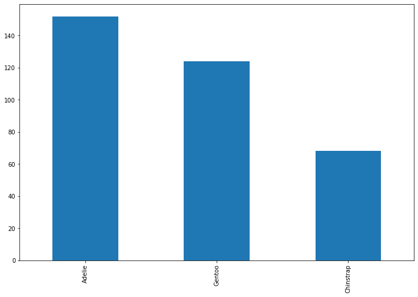

```python
fig, ax = plt.subplots(figsize=(12, 8))

penguins.species.value_counts().plot(kind='bar', ax=ax)

plt.show()
```

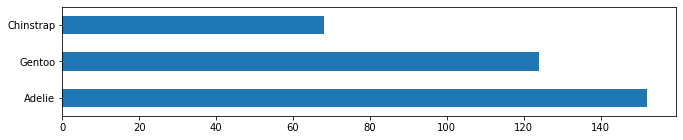

```python
fig2, ax = plt.subplots(figsize=(11, 2))

penguins.species.value_counts().plot(kind='barh', ax=ax)

plt.show()
```

Seaborn will do the counting for us with the `sns.countplot()` is an axes-level function to create a bar chart.

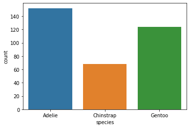

```python
sns.countplot(data = penguins, x='species')

plt.show()
```

To make a horizontal bar chart we use the `y` variable instead of `x` in `sns.countplot()`.

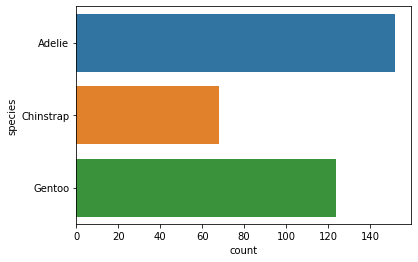

```python
sns.countplot(data = penguins, y='species')

plt.show()
```

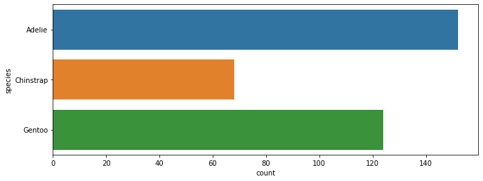

```python
fig, ax = plt.subplots(figsize=(11, 4))

sns.countplot(data = penguins, y='species', ax=ax)

plt.show()
```

To make a bar chart we can also use the **figure level** function `sns.catplot()`.

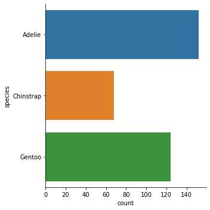

```python
sns.catplot(data = penguins, y='species', kind='count')

plt.show()
```

We can control the facets (subplots) with the `col` and `row` argument to figure level Seaborn functions.

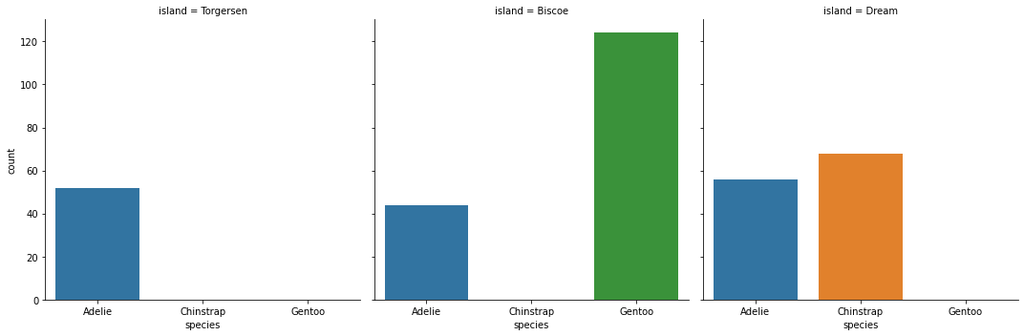

```python
sns.catplot(data = penguins, x='species', kind='count', col='island')

plt.show()
```

Create a **dodged bar chart** where the side-by-side bars of different color denote the values of another variable.

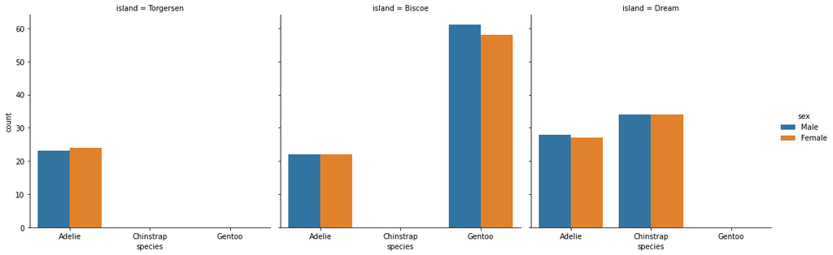

```python
sns.catplot(data = penguins, x='species', kind='count', col='island', hue='sex')

plt.show()
```

Check these numbers make sense by grouping and aggregating.

```python
penguins.groupby(['island', 'species', 'sex']).size().reset_index(name='num_rows')
```

|  | island | species | sex | num_rows |
| --- | --- | --- | --- | --- |
| 0 | Biscoe | Adelie | Female | 22 |
| 1 | Biscoe | Adelie | Male | 22 |
| 2 | Biscoe | Gentoo | Female | 58 |
| 3 | Biscoe | Gentoo | Male | 61 |
| 4 | Dream | Adelie | Female | 27 |
| 5 | Dream | Adelie | Male | 28 |
| 6 | Dream | Chinstrap | Female | 34 |
| 7 | Dream | Chinstrap | Male | 34 |
| 8 | Torgersen | Adelie | Female | 24 |
| 9 | Torgersen | Adelie | Male | 23 |

Heat maps are another option for displaying counts of combinations. I like to make heat maps from **cross-tabulations**.

For example, let's get the number of rows for each combination of island and species.

```python
penguins.groupby(['island', 'species']).size().reset_index(name='num_rows')
```

|  | island | species | num_rows |
| --- | --- | --- | --- |
| 0 | Biscoe | Adelie | 44 |
| 1 | Biscoe | Gentoo | 124 |
| 2 | Dream | Adelie | 56 |
| 3 | Dream | Chinstrap | 68 |
| 4 | Torgersen | Adelie | 52 |

```python
pd.crosstab( penguins.island, penguins.species )
```

| species island | Adelie | Chinstrap | Gentoo |
| --- | --- | --- | --- |
| Biscoe | 44 | 0 | 124 |
| Dream | 56 | 68 | 0 |
| Torgersen | 52 | 0 | 0 |

Visualize the cross-tabulation as a heatmap.

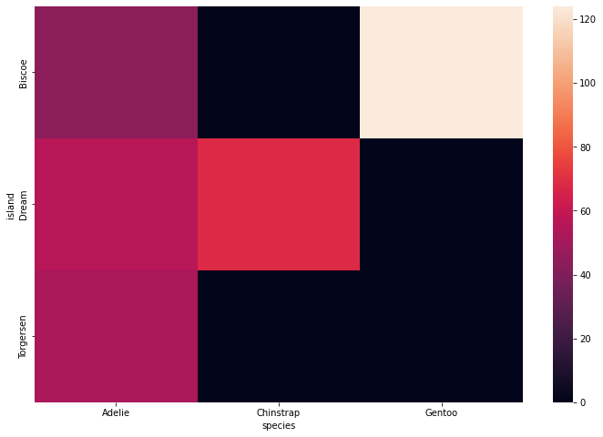

```python
fig, ax = plt.subplots(figsize=(12, 8))

sns.heatmap(pd.crosstab( penguins.island, penguins.species ), ax=ax )

plt.show()
```

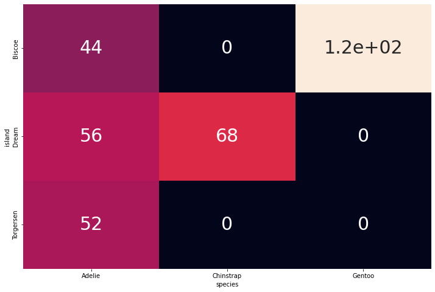

```python
fig, ax = plt.subplots(figsize=(12, 8))

sns.heatmap(pd.crosstab( penguins.island, penguins.species ), ax=ax,
            annot=True, annot_kws={'size': 30}, cbar=False)

plt.show()
```

## Histogram

Make a histogram for the `flipper_length_mm` variable.

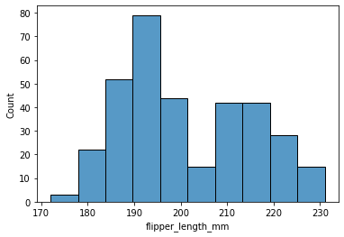

```python
sns.histplot(data = penguins, x='flipper_length_mm')

plt.show()
```

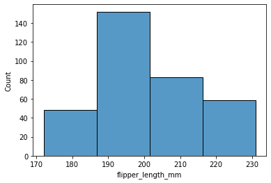

```python
sns.histplot(data = penguins, x='flipper_length_mm', bins=4)

plt.show()
```

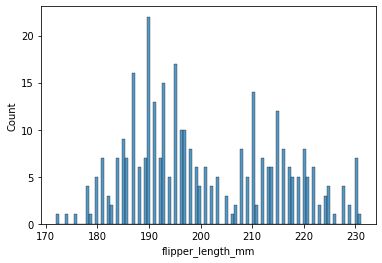

```python
sns.histplot(data = penguins, x='flipper_length_mm', bins=101)

plt.show()
```

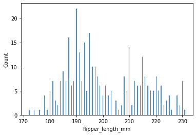

```python
sns.histplot(data = penguins, x='flipper_length_mm', bins=225)

plt.show()
```

Make a categorical variable out of the continuous variable.

```python
penguins_b = penguins.copy()
```

```python
penguins_b['flipper_cat'] = pd.cut( penguins_b.flipper_length_mm, bins=4, include_lowest=True, ordered=True )
```

```python
penguins_b.flipper_cat.value_counts()
```

```
(186.75, 201.5]     152
(201.5, 216.25]      83
(216.25, 231.0]      59
(171.94, 186.75]     48
Name: flipper_cat, dtype: int64
```

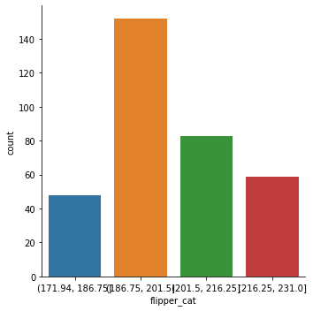

```python
sns.catplot(data = penguins_b, x='flipper_cat', kind='count')

plt.show()
```

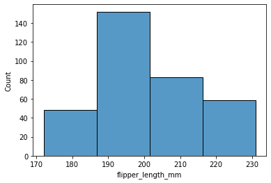

```python
sns.histplot(data = penguins, x = 'flipper_length_mm', bins=4)

plt.show()
```

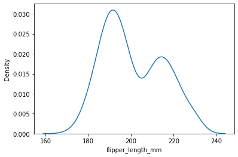

```python
sns.kdeplot(data = penguins, x='flipper_length_mm')

plt.show()
```

Use colors to denote the grouping by a categorical variable.

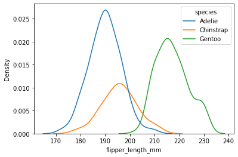

```python
sns.kdeplot(data = penguins, x='flipper_length_mm', hue='species')

plt.show()
```

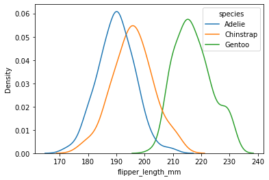

```python
sns.kdeplot(data = penguins, x='flipper_length_mm', hue='species', common_norm=False)

plt.show()
```

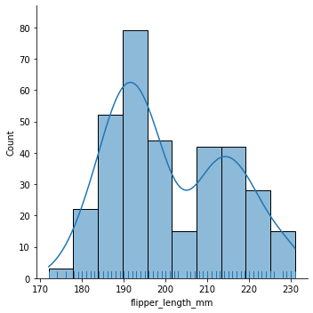

```python
sns.displot(data = penguins, x='flipper_length_mm', kde=True, rug=True)

plt.show()
```

### Boxplots to summarize a continuous variable by a categorical

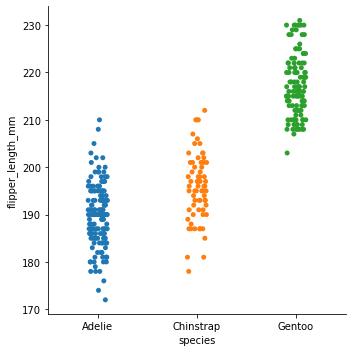

```python
sns.catplot(data = penguins, x='species', y='flipper_length_mm')

plt.show()
```

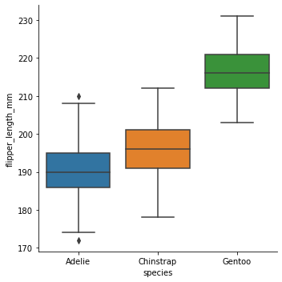

```python
sns.catplot(data = penguins, x='species', y='flipper_length_mm', kind='box')

plt.show()
```

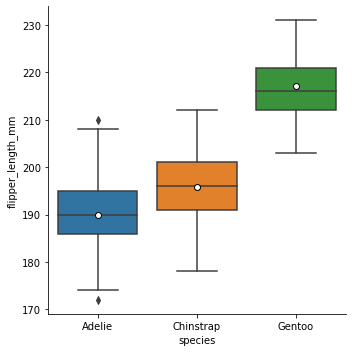

```python
sns.catplot(data = penguins, x='species', y='flipper_length_mm', kind='box',
            showmeans=True,
            meanprops={'marker': 'o', 'markerfacecolor': 'white', 'markeredgecolor': 'black'})

plt.show()
```

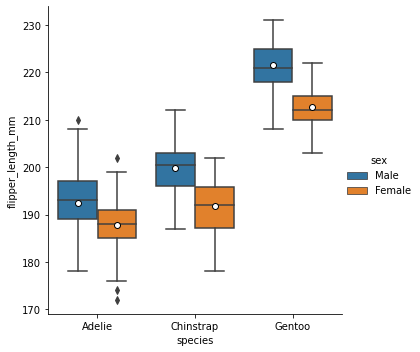

```python
sns.catplot(data = penguins, x='species', y='flipper_length_mm', kind='box', hue='sex',
            showmeans=True,
            meanprops={'marker': 'o', 'markerfacecolor': 'white', 'markeredgecolor': 'black'})

plt.show()
```

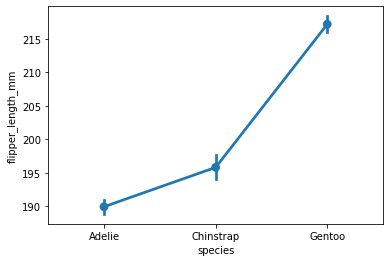

```python
sns.pointplot(data = penguins, x='species', y='flipper_length_mm', ci=95)

plt.show()
```

## Continuous to continuous variable relationship

Scatter plot.

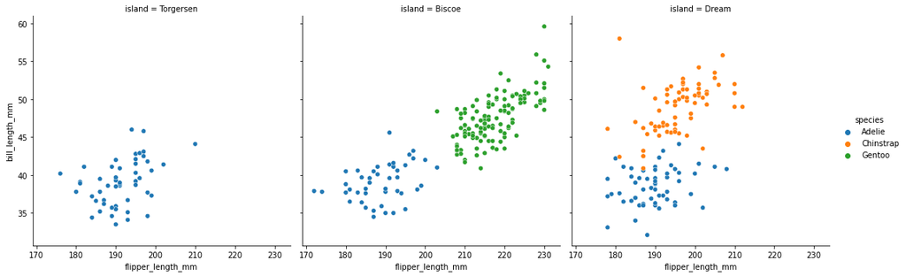

```python
sns.relplot(data = penguins, x='flipper_length_mm', y='bill_length_mm', hue='species', col='island')

plt.show()
```

### Trend lines

sns.lmplot()

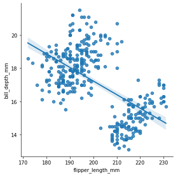

```python
sns.lmplot(data = penguins, x='flipper_length_mm', y='bill_depth_mm')

plt.show()
```

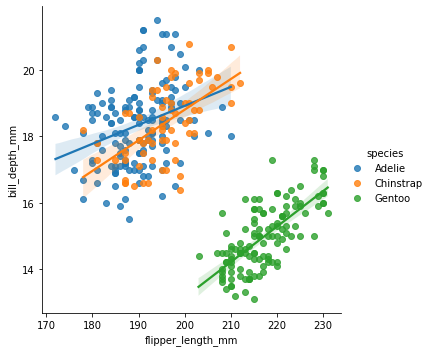

```python
sns.lmplot(data = penguins, x='flipper_length_mm', y='bill_depth_mm', hue='species')

plt.show()
```

```python
penguins.info()
```

```
<class 'pandas.core.frame.DataFrame'>
RangeIndex: 344 entries, 0 to 343
Data columns (total 7 columns):
 #   Column             Non-Null Count  Dtype
---  ------             --------------  -----
 0   species            344 non-null    object
 1   island             344 non-null    object
 2   bill_length_mm     342 non-null    float64
 3   bill_depth_mm      342 non-null    float64
 4   flipper_length_mm  342 non-null    float64
 5   body_mass_g        342 non-null    float64
 6   sex                333 non-null    object
dtypes: float64(4), object(3)
memory usage: 18.9+ KB
```